# Previous years users

Group members: Henrik Syversveen Lie, Mikal Solberg Stapnes

# Problem A

```r
# The function g(x) from problem A.2
g = function(x, alpha) {
    c = alpha * exp(1)/(alpha + exp(1))
    result = vector(length = length(x))
    result[x < 1] = c * x[x < 1]^(alpha - 1)
    result[x >= 1] = c * exp(-x[x >= 1])
    return(as.double(result))
}
# The following function returns n from the density function g(x) by
# doing inversion sampling
G_inv = function(n, alpha) {
    c = alpha * exp(1)/(alpha + exp(1))
    u = runif(n)
    result = vector(length = n)
    result[u < c/alpha] = (alpha/c * u[u < c/alpha])^(1/alpha)
    result[u >= c/alpha] = -log(1/alpha + exp(-1) - u[u >= c/alpha]/c)
    return(result)
}
alpha = 0.43
n = 1e+05
xsamples = G_inv(n, alpha)  # Sample from the density function g(x) by inversion sampling
c = alpha * exp(1)/(alpha + exp(1))
mean = c/(alpha + 1) + 2 * c/exp(1)
cat("Theoretical mean: ", mean, " Sampled mean: ", mean(xsamples))
```

```
## Theoretical mean:  0.5327939  Sampled mean:  0.5341024
```

Then we compute the theoretical variance by $\text{Var}(X) = \text{E}(X^2)-\text{E}(X)^2$ and compare it with the sampled variance. The theoretical variance will be
$$\text{Var}(X) = \text{E}(X^2) - \text{E}(X)^2 = \frac{c}{\alpha+2}+\frac{5c}{e} - \big(\frac{c}{\alpha+1} + \frac{2c}{e}\big)^2.$$

We compare results in R

```r
variance = c/(alpha + 2) + 5 * c/exp(1) - mean^2
cat("Theoretical variance: ", variance, " Sampled variance: ", var(xsamples))
```

```
## Theoretical variance:  0.5518286  Sampled variance:  0.5506962
```

We see that the sampled mean and variance coincide with the theoretical mean and variance. To conclude on the correctness of our algorithm, we also make a histogram of the sample and compare it to the density function $g(x)$.

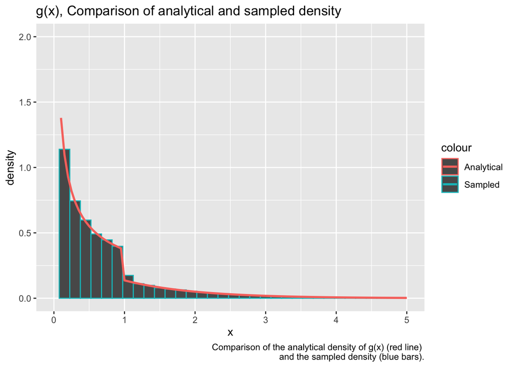

```r
# Prepare generated samples for plotting by putting them in a
# dataframe
df2 <- data.frame(theo = seq(0, max(xsamples), length.out = n), value = xsamples)
# Plot the data
ggplot(df2, aes(x = value)) + geom_histogram(aes(y = ..density.., color = "Sampled"),
    binwidth = 0.15) + stat_function(fun = g, geom = "line", size = 1,
    args = (mean = alpha), alpha = 1, aes(color = "Analytical")) + ggtitle("g(x), Comparison of analytical and sampled density") +
    ylim(0, 2) + xlim(0, 5) + labs(x = "x", y = "density", caption = paste("Comparison of the analytical density of g(x) (red line) \n and the sampled density (blue bars)."))
```

# Problem B: The gamma distribution

## 1.

We can sample from the Gamma distribution with $\alpha \in (0, 1)$ and $\beta = 1$,

$$f_X(x) = \begin{cases}
\frac{1}{\Gamma(\alpha)}x^{\alpha-1}e^{-x}, \quad & 0<x,\\
0, \quad &\text{otherwise}, \\
\end{cases}$$

using rejection sampling with the distribution $g(x)$ found in A.2 as a proposal distribution. We can do this because $g(x)$ is nonzero at all points where $f_X(x)$ is nonzero. As a result, we can find $c$ s.t. $f_X(x) \leq cg(x)$ for all $x$.

To generate $n$ samples from $f_X(x)$ we sample from $X \sim g(x)$ and $U \sim u[0, 1]$, and accept the sample $x$ if $u \leq \frac{f_X(x)}{c g(x)}$. We note that the overall acceptance probabiltiy, $P_{\text{accept}}$, is
$$P_{\text{accept}} = P\bigg(U\leq \frac{1}{c}\frac{f_X(x)}{g(x)}\bigg) = \int_0^{\infty} \frac{f_X(x)}{c g(x)} g(x)dx = c^{-1}.$$

To maximize this acceptance probability, we minimize $c$ by choosing

$$c = \underset{x}{\sup} \frac{f_X(x)}{g(x)} = \underset{x}{\sup} \begin{cases}
\frac{e^{-x}(\frac{1}{\alpha} + \frac{1}{e})}{\Gamma(\alpha)}, \quad 0 \leq x \le 1 \\
\frac{x^{\alpha - 1} (\frac{1}{\alpha} + \frac{1}{e})}{\Gamma(\alpha)}, \quad 1 \leq x
\end{cases},$$
which gives $c = \frac{(\frac{1}{\alpha} + \frac{1}{e})}{\Gamma(\alpha)}$.

We implement a function in R that generates $n$ samples from $f_X(x)$ by the rejection algorithm.

```r
small_gamma = function(alpha, n = 1) {
    result = vector()
    iter = 0
    sampled = 0
    c = (1/alpha + exp(-1))/gamma(alpha)

    while (sampled < n) {
        # Sample n realizations from g(x)
        x = G_inv(n, alpha)
        # Compute the acceptance probabilites for the n realizations
        probs = dgamma(x, alpha, rate = 1)/(c * as.double(g(x, alpha)))
        # Generate n samples from U(0,1)
        u = runif(n)
        # Append samples where u < f(x) / c g(x)
        result = append(result, x[u <= probs])
        # Increase counters
        sampled = sampled + sum(u <= probs)
        iter = iter + n
    }
    # If redundant samples were generated, we do not want to count these
    # as iterations
    iter = iter - length(result) + n
    # If redundant samples were generated, return only n samples
    return(list(samples = result[seq(1:n)], iter = iter))
}
```

We compare the sample mean and variance with the theoretical mean and variance and compare the sampled density with the analytical density.

```r
alpha = 0.95
G1 <- small_gamma(alpha, 10000)  # Generate samples
df = data.frame(G1)  # Put samples in dataframe to prepare for plotting
cat("Theoretical mean: ", alpha, " Computed mean: ", mean(G1$samples),
    "\n")
```

```
## Theoretical mean:  0.95  Computed mean:  0.9543477
```

```r
cat("Theoretical variance: ", alpha, " Computed variance: ", var(G1$samples))
```

```
## Theoretical variance:  0.95  Computed variance:  0.9474447
```

We see that the computed mean and variance coincide with the theoretical mean and variance.

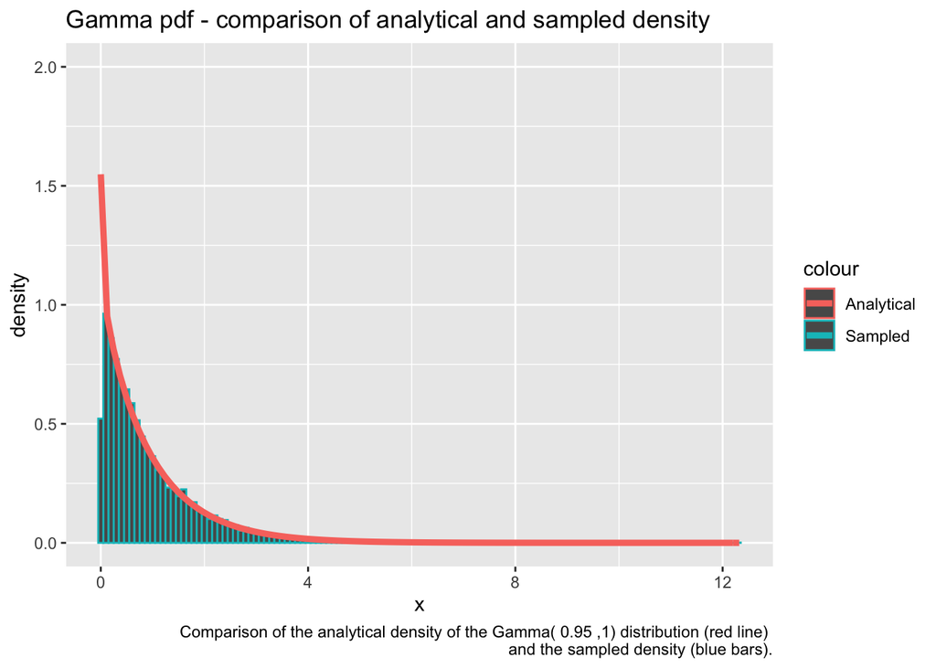

```r
ggplot(data = df, aes(x = samples)) + geom_histogram(data = df, aes(x = samples,
    y = ..density.., color = "Sampled"), binwidth = 0.1) + stat_function(fun = dgamma,
    geom = "line", size = 1.6, args = list(shape = alpha, rate = 1),
    aes(x = samples, color = "Analytical")) + ggtitle("Gamma pdf - comparison of analytical and sampled density") +
    ylim(0, 2) + labs(x = "x", y = "density", caption = paste("Comparison of the analytical density of the Gamma(",
    alpha, ",1) distribution (red line) \n and the sampled density (blue bars)."))
```

From the figure we see that we get the correct distribution when using rejection sampling.

## 2.

As we remove the limitation on $\alpha$, we no longer get a closed form expression for the $c$ giving the highest acceptance probability. Instead, we may use the ratio of uniforms method to sample from the Gamma distribution with parameters $\alpha > 1$, $\beta = 1$. We define the area $C_f$,

$$C_f = \bigg \{(x_1, x_2): 0 \leq x_1 \leq \sqrt{f^*(\frac{x_2}{x_1})} \bigg \}, \quad f^*(x) = \begin{cases}
x^{\alpha-1}e^{-x}, \quad 0 < x, \\
0, \quad \text{otherwise}.
\end{cases}$$
Then we note that $y = x_2 / x_1$ will be Gamma-distributed if sampled uniformly inside $C_f$. By finding

$$a = \sqrt{\sup_x f^* (x)}, \quad b_{+} = \sqrt{ \sup_{x\geq 0} x^2 f^* (x)} , \quad b_{\_} = - \sqrt{\sup_{x \leq 0} x^2 f^* (x)},$$

$$\begin{gather*}
(f^\ast(x))' = 0 \Leftrightarrow x^{\alpha-2}e^{-x}(\alpha - 1 - x) = 0 \Rightarrow x = \alpha - 1 \\
a = \sqrt{(\alpha - 1)^{\alpha - 1}e^{1-\alpha}},
\end{gather*}$$

$$\begin{gather*}
(x^2 f^\ast(x))' = 0 \Leftrightarrow x^{\alpha}e^{-x}(\alpha + 1 - x) = 0 \Rightarrow x = \alpha + 1 \\
b_{+} = \sqrt{(\alpha + 1)^{\alpha + 1}e^{-\alpha - 1}},
\end{gather*}$$

$$b_{-} = 0,$$

we can sample uniformly from $[0, a]\times[b_{-}, b_{+}]$ and select the set of samples that are also in $C_f$. Then $y = \frac{x_2}{x_1}$ will be Gamma($\alpha ,1$) distributed. Note that in the code below, we check if $(x_1, x_2) \in C_f$ on a log-scale as $\log a, \log b$ are more easily stored than $a, b$ when $\alpha$ becomes large. The equivalent condition becomes
$$\log x_1 = \log a + \log u_1, \quad u_1 \sim U[0, 1]$$
$$\log x_2 = \log b + \log u_2, \quad u_2 \sim U[0, 1]$$
$$(x_1, x_2) \in C_f \Leftrightarrow 2 \log x_1 \leq (\alpha-1)(\log x_2 - \log x_1) - \exp\{\log x_2 - \log x_1\}.$$

```r
large_gamma <- function(alpha, n = 1) {
    # Log transformations of a and b+
    loga = 1/2 * (alpha - 1) * (log(alpha - 1) - 1)
    logb = 1/2 * (alpha + 1) * (log(alpha + 1) - 1)
    result = vector(mode = "numeric")

    accepted_samples = 0
    iter = 0
    while (accepted_samples < n) {
        iter = iter + 1
        log_x_1 = loga + log(runif(1))
        log_x_2 = logb + log(runif(1))
        # Accept sample if equivalent condition of (x_1, x_2) in C_f is met
        if (2 * log_x_1 <= (alpha - 1) * (log_x_2 - log_x_1) - exp(log_x_2 -
            log_x_1)) {
            result = append(result, exp(log_x_2 - log_x_1))
            accepted_samples = accepted_samples + 1
        }
    }
    list(samples = result, iter = iter)
}
```

We then generate samples with our algorithm and conduct tests to check its correctness.

```r
alpha = 7
n = 10000
G2 = large_gamma(alpha, n)  # Generate samples
cat("Theoretical mean: ", alpha, " Computed mean: ", mean(G2$samples),
    "\n")
```

```
## Theoretical mean:  7  Computed mean:  6.983786
```

```r
cat("Theoretical variance: ", alpha, " Computed variance: ", var(G2$samples))
```

```
## Theoretical variance:  7  Computed variance:  7.02712
```

We see that the computed mean and variance coincide with the theoretical mean and variance.

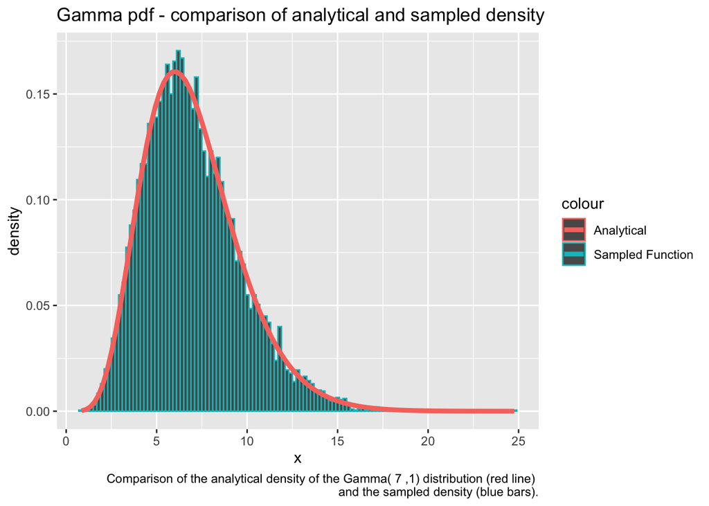

```r
df = data.frame(data = G2)
ggplot(df, aes(x = data.samples)) + geom_histogram(data = df, aes(x = data.samples,
    y = ..density.., color = "Sampled Function"), binwidth = 0.2) + stat_function(fun = dgamma,
    geom = "line", size = 1.6, aes(color = "Analytical"), args = list(shape = alpha,
        rate = 1)) + ggtitle("Gamma pdf - comparison of analytical and sampled density") +
    labs(x = "x", y = "density", caption = paste("Comparison of the analytical density of the Gamma(",
        alpha, ",1) distribution (red line) \n and the sampled density (blue bars)."))
```

From the figure we see that we get the correct distribution when sampling using the ratio of uniforms method.

We wish to investigate in what manner $\alpha$ affects the acceptance probability $P$ of the ratio of uniforms method. We draw $n = 1000$ samples for $\alpha \in (2, 2002]$ and count, for each $\alpha$, the average number of iterations of the rejection sampling algorithm required to sample one gamma-distributed variable. The inverse of this will then be an estimate of the acceptance probability.

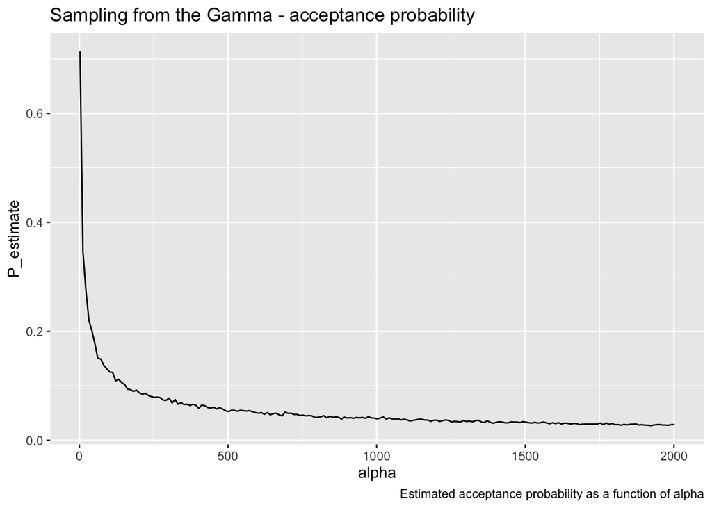

```r
# The following function returns number of iterations required to
# generate 1000 samples from the large_gamma function
get_gamma_iterations <- function(alpha) {
    return(large_gamma(alpha, 1000)$iter)
}
alpha = seq(2, 2002, 10)  # Specify the alphas
iterations <- sapply(alpha, get_gamma_iterations)  # Compute number of iterations for each alpha
df = data.frame(alpha = seq(2, 2002, 10), P_estimate = 1000/iterations)  # Put data in dataframe to prepare for plotting
ggplot(df, aes(x = alpha, y = P_estimate)) + geom_line() + ggtitle("Sampling from the Gamma - acceptance probability") +
    labs(caption = "Estimated acceptance probability as a function of alpha")
```

From the plot we see that $P_accept$ decreases with larger $\alpha$. This is as expected; with increasing $\alpha$, the pdf flattens out and the proportion of the area in $[0, a]\times[b_{-}, b_{+}]$ covered by $C_{f}$ decreases.

We now have reasonably efficient algorithms for sampling from the Gamma with $\alpha \in (0, 1), \beta = 1$ and $\alpha \in (1, \infty), \beta = 1$. We note that for $\alpha = 1, \beta = 1$, the pdf of the Gamma coincides with the unscaled exponential distribution. We also note that $\beta$ is an inverse scale parameter, and $\frac{1}{\beta}X \sim Gamma(\alpha, \beta)$ if $X \sim Gamma(\alpha, 1)$. We use this and our two algorithms to develop a general algorithm for sampling from the Gamma distribution.

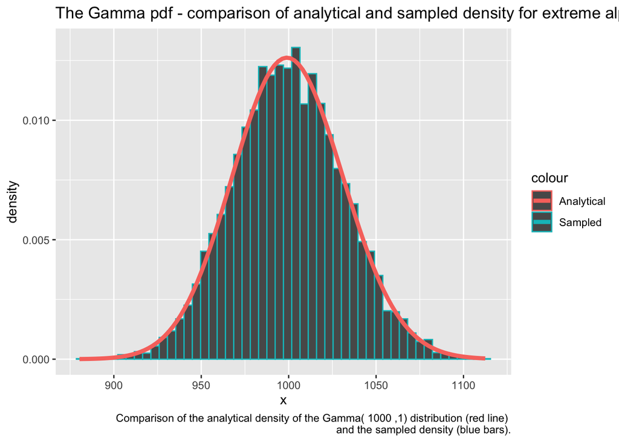

```r
# As specified above, gamma2 samples using rejection sampling for
# alpha < 1, and the ratio of uniforms method for alpha > 1. If alpha
# = 1 we sample from the exponential
gamma2 = function(alpha, beta = 1, n = 1) {
    if (alpha == 1) {
        return(list(samples = exponential(beta, n), iter = n))
    } else if (alpha <= 1) {
        G = small_gamma(alpha, n)
        # Insert rate / scale parameters
        G$samples = G$samples/beta
        return(G)
    } else if (alpha > 1) {
        G = large_gamma(alpha, n)
        # Insert rate / scale parameters
        G$samples = G$samples/beta
        return(G)
    }
}
n = 10000
alpha = 1000
beta = 1
G = gamma2(alpha, beta, n)  # Draw samples
df <- data.frame(G)  # Prepare samples for plotting
histo = hist(G$samples, plot = F)  # Compute the sampled density
# Plot results
ggplot(df, aes(x = samples)) + geom_histogram(aes(y = ..density.., color = "Sampled"),
    bins = 50) + stat_function(fun = dgamma, geom = "line", size = 1.6,
    aes(color = "Analytical"), args = list(shape = alpha, rate = beta)) +
    ggtitle("The Gamma pdf - comparison of analytical and sampled density for extreme alpha") +
    ylim(0, 1.1 * max(histo$density)) + labs(x = "x", y = "density",
    caption = paste("Comparison of the analytical density of the Gamma(",
        alpha, ",1) distribution (red line) \n and the sampled density (blue bars)."))
```

We note that as $\alpha \rightarrow \infty$, as in the figure above, the Gamma pdf approaches a normal distribution. Taking advantage of this, sophisticated sampling techniques modify samples from the normal when sampling from the Gamma with very large $\alpha$.

# Problem A: Stochastic simulation by the probability integral transform and bivariate techniques

## 1.

We will write a function that generates $n$ samples from an exponential distribution with rate $\lambda$. This is performed by first drawing samples from $u\sim U(0,1)$. It then follows that the transformation $x=-\log(u)/\lambda$ follows a exponential distribution with rate $\lambda$.

```r
rexp <- function(n, rate = 1) {
    u <- runif(n = n)  # Draw from standard uniform distribution
    x <- -log(u)/rate  # Transformation to get exponentially distributed variables.
    return(enframe(x))  # Return a vector with the generated random numbers.
}
```

In order to check correctness of the algorithm we compare sample mean and variance with the theoretical solution. We already know that $\mathrm{E}(X)=1/\lambda$ and $\mathrm{Var}(X)=1/\lambda^2$ when $X\sim \mathrm{Exp}(\lambda)$. We draw $n=50000$ samples with $\lambda=2.0$ and compare with theoretical solutions.

```r
n = 50000
rate = 2
x = rexp(n, rate)
results <- list(mean = 1/rate, sample_mean = mean(x$value), variance = 1/rate^2,
    sample_variance = var(x$value))
print(results)
```

```
## $mean
## [1] 0.5
##
## $sample_mean
## [1] 0.50224
##
## $variance
## [1] 0.25
##
## $sample_variance
## [1] 0.2546829
```

The algortihm seems to be correct as sampled mean and variance are very close to the theoretical. Further, we compare histogram of random sample to analytical solution.

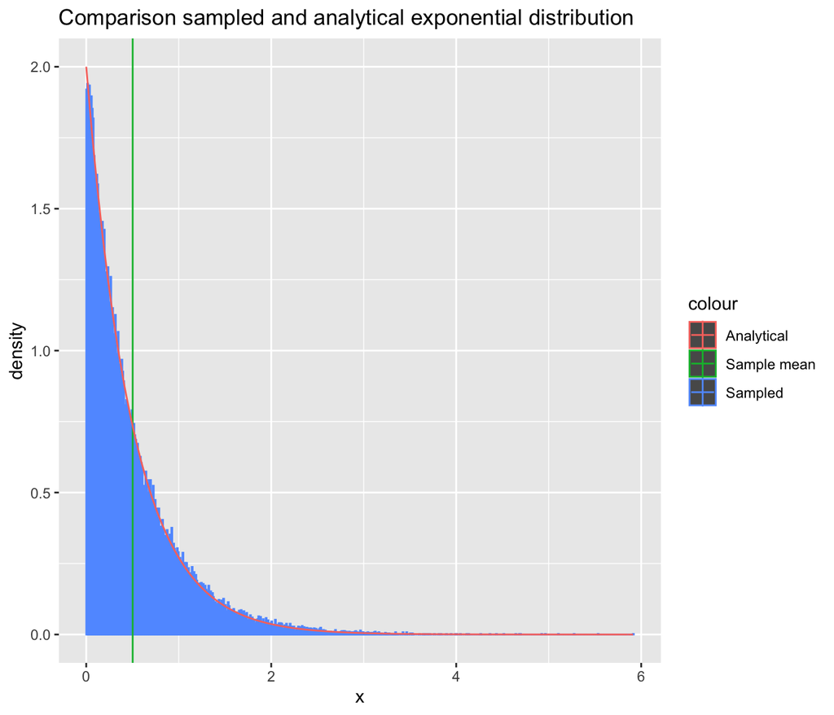

**Figure 1**: Comparison of sampled and analytical exponential distribution. Sampled density shown in blue bars and analytical in red line. Sample mean is green vertical line.

```r
ggplot() + geom_histogram(data = x, mapping = aes(x = value, y = ..density..,
    color = "Sampled"), binwidth = 0.01, boundary = 0) + geom_vline(aes(xintercept = mean(x$value),
    color = "Sample mean")) + stat_function(fun = dexp, args = list(rate = rate),
    aes(col = "Analytical")) + ggtitle("Comparison sampled and analytical exponential distribution") +
    labs(x = "x", y = "density")
```

From **figure 1** we see that there is overlap between density of samples and analytical solution. Hence, our algorithm seems to be correct.

## 2.

## (a)

Consider the probability density function
$$\begin{align}
g(x) =
\begin{cases}
cx^{\alpha-1},\,\, &0<x<1,\\
ce^{-x},\,\, &1\leq x,\\
0, \,\, &\text{otherwise}
\end{cases}
\end{align}$$
where $c$ is normalizing constant and $\alpha\in (0,1)$. We find the normalizing constant by integration
$$\begin{align}
1=\int_{0}^{\infty}g(x)\,dx=\int_{0}^1 cx^{\alpha-1}\,dx+\int_{1}^{\infty}ce^{-x}\,dx=c\frac{\alpha+e}{\alpha e}
\end{align}$$
Hence the normalizing constant equals $c=\frac{e\alpha}{e+\alpha}$.

It then follows that the density function is given by
$$\begin{align}
g(x) =
\begin{cases}
\frac{e\alpha}{e+\alpha}x^{\alpha-1},\,\, &0<x<1,\\
\frac{e\alpha}{e+\alpha}e^{-x},\,\, &1\leq x,\\
0, \,\, &\text{otherwise}
\end{cases}
\end{align}$$

The cumulative distribution is then given by
$$\begin{align}
F(x)=\mathrm{P}(X\leq x) = \int_{0}^x g(z)\,dz=
\begin{cases}
0, \,\, &x \leq 0,\\
\frac{e\alpha}{e+\alpha}\frac{x^{\alpha}}{\alpha} = \frac{e}{e+\alpha}x^{\alpha},\,\, &0<x<1,\\
\frac{\frac{e\alpha}{e+\alpha}}{e}+\frac{\frac{e\alpha}{e+\alpha}}{\alpha}-\frac{e\alpha}{e+\alpha}e^{-x} = 1-\frac{e\alpha}{e+\alpha}e^{-x},\,\, &1\leq x,
\end{cases}
\end{align}$$

In order to find the inverse of $F(x)$ we first look at the case when $F(x)<\frac{e}{e+\alpha}$
$$\begin{align}
F(x)=\frac{e}{e+\alpha} \implies x=\left(\frac{\alpha+e}{e}F(x)\right)^{1/\alpha}
\end{align}$$
For $F(x)>\frac{e}{e+\alpha}$
$$\begin{align}
F(x)=1-\frac{\alpha e}{\alpha+e}e^{-x}\implies x=-\ln\left(\frac{\alpha+e}{\alpha e}(1-F(x))\right)
\end{align}$$

Hence, the inverse of the cumulative distribution $F(x)$ becomes
$$\begin{align}
F^{-1}(x)=
\begin{cases}
\left(\frac{\alpha+e}{e}x\right)^{1/\alpha},\,\, &0\leq x \leq \frac{e}{e+\alpha}\\
-\ln\left(\frac{\alpha+e}{\alpha e}(1-x)\right), \,\, &\frac{e}{e+\alpha}\leq x \leq 1
\end{cases}
\end{align}$$

Now we can use $F^{-1}(x)$ to sample from the target distribution $g(x)$ using the inversion method. First we generate a random variable $U$ from the standard uniform distribution in the interval $[0,1]$ and then it follows that $X=F^{-1}(U)$ is a random variable from the target distribution $g(x)$.

The mean is found by
$$\begin{align}
\mathrm{E}(X)=\int_{-\infty}^{\infty}xg(x)\,dx=\frac{c}{1+\alpha}+\frac{2c}{e}
\end{align}$$
The variance is then found by $\mathrm{Var}(X)=\mathrm{E}(X^2)-\mathrm{X}^2$. We have that
$$\begin{align}
\mathrm{E}(X^2)=\int_{0}^{\infty}x^2 g(x)\,dx=c\int_{0}^1 x^{\alpha+1}\,dx+c\int_{1}^{\infty}x^2e^{-x}\,dx=\frac{c}{2+\alpha}+\frac{5c}{e}
\end{align}$$
and thus
$$\begin{align}
\mathrm{Var}(X)=\frac{c}{2+\alpha}+\frac{5c}{e}-\left(\frac{c}{1+\alpha}+\frac{2c}{e}\right)
\end{align}$$

## (b)

Since we have an analytical formula for the cumulative distribution we can use the inversion method to sample from $g(x)$.

```r
rg = function(n, alpha) {
    u = runif(n = n)
    boundary = exp(1)/(alpha + exp(1))
    left_boundary = u < boundary
    right_boundary = !left_boundary

    u[left_boundary] = (u[left_boundary]/boundary)^(1/alpha)
    u[right_boundary] = -log((1 - u[right_boundary])/(boundary * alpha))
    return(enframe(u))
}
```

For comparison we also implement the density function $g(x)$

```r
dg = function(x, alpha = 1) {
    c = alpha * exp(1)/(alpha + exp(1))
    d <- rep(0, length(x))
    left_indices <- 0 < x & x < 1
    right_indices <- 1 <= x
    d[left_indices] <- c * (x[left_indices]^(alpha - 1))
    d[right_indices] <- c * exp(-x[right_indices])
    return(d)
}
```

We now compare the inversion method with 100000 random samples to the theoretical density.

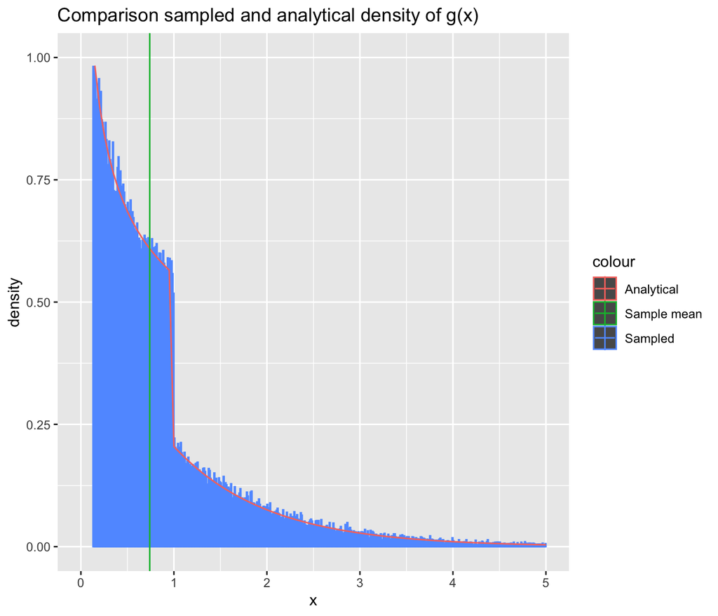

**Figure 2**: Comparing analytical and sampled density. Sampled density shown in blue bars and analytical of g(x) in red line. Sample mean is green vertical line.

```r
samples <- 1e+05
alpha <- 0.7
g_samples <- rg(n = samples, alpha = alpha)
ggplot() + geom_histogram(data = g_samples, mapping = aes(x = value,
    y = ..density.., color = "Sampled"), binwidth = 0.01, boundary = 0) +
    stat_function(fun = dg, args = list(alpha = alpha), aes(col = "Analytical")) +
    geom_vline(aes(xintercept = mean(g_samples$value), col = "Sample mean")) +
    ylim(0, 1) + xlim(0, 5) + ggtitle("Comparison sampled and analytical density of g(x)") +
    labs(x = "x", y = "density")
```

From **figure 2** we see that the analytical density overlaps with the sampled density and algorithm seems to work. We know compare sampled mean and variance with theoretical mean and variance.

```r
library(magrittr)
c <- alpha * exp(1)/(alpha + exp(1))
mean <- c * (1/(alpha + 1) + 2/exp(1))
second_moment <- c * (1/(alpha + 2) + 5/exp(1))
variance <- second_moment - mean^2
results <- list(mean = mean, sample_mean = mean(g_samples %>% use_series(value)),
    variance = variance, sample_variance = var(g_samples %>% use_series(value)))
print(results)
```

```
## $mean
## [1] 0.7370055
##
## $sample_mean
## [1] 0.7399536
##
## $variance
## [1] 0.6868969
##
## $sample_variance
## [1] 0.6890531
```

We also see that sampled and theoretical values coincide and conclude that the algorithm works.

## 3.

Consider the probability density function

$$\begin{align}
f(x)=\frac{ce^{\alpha x}}{(1+e^{\alpha x})^2}, \quad -\infty < x < \infty, \, \alpha > 0
\end{align}$$

where $c$ is a normalizing constant.

## (a)

We find the normalizing constant by integration

$$\begin{align}
1=\int_{\mathcal{R}}f(x)\,dx=\int_{-\infty}^{\infty}\frac{ce^{\alpha x}}{(1+e^{\alpha x})^2}\,dx=
c\int_{1}^{\infty}\frac{e^{\alpha x}}{u^2}\frac{du}{\alpha e^{\alpha x}}=
\frac{c}{\alpha}\int_{1}^{\infty}\frac{1}{u^2}\,du
=-\frac{c}{\alpha}\frac{1}{u}\Big|_{1}^{\infty}=\frac{c}{\alpha} \implies c=\alpha
\end{align}$$

where we have used the substitution $u = 1+e^{\alpha x}$ and thus $du=\alpha e^{\alpha x}\,dx$.

Inserting $c$ into the density function yields

$$\begin{align}
f(x)=\frac{\alpha e^{\alpha x}}{(1+e^{\alpha x})^2}, \quad -\infty < x < \infty, \, \alpha > 0
\end{align}$$

## (c)

Since we have an analytical formula for the cumulative distribution we can use the inversion method to sample from f(x).

```r
rf = function(n, alpha) {
    u = runif(n = n)
    x = log(-u/(u - 1))/alpha
    return(enframe(x))
}
```

For comparison we also implement the density function $f(x)$

```r
df = function(x, alpha) {
    c = alpha
    d = rep(0, length(x))
    d = c * exp(alpha * x)/((1 + exp(alpha * x))^2)
}
```

We now compare the inversion method with 10000000 random samples to the theoretical density. We set $\alpha=0.7$.

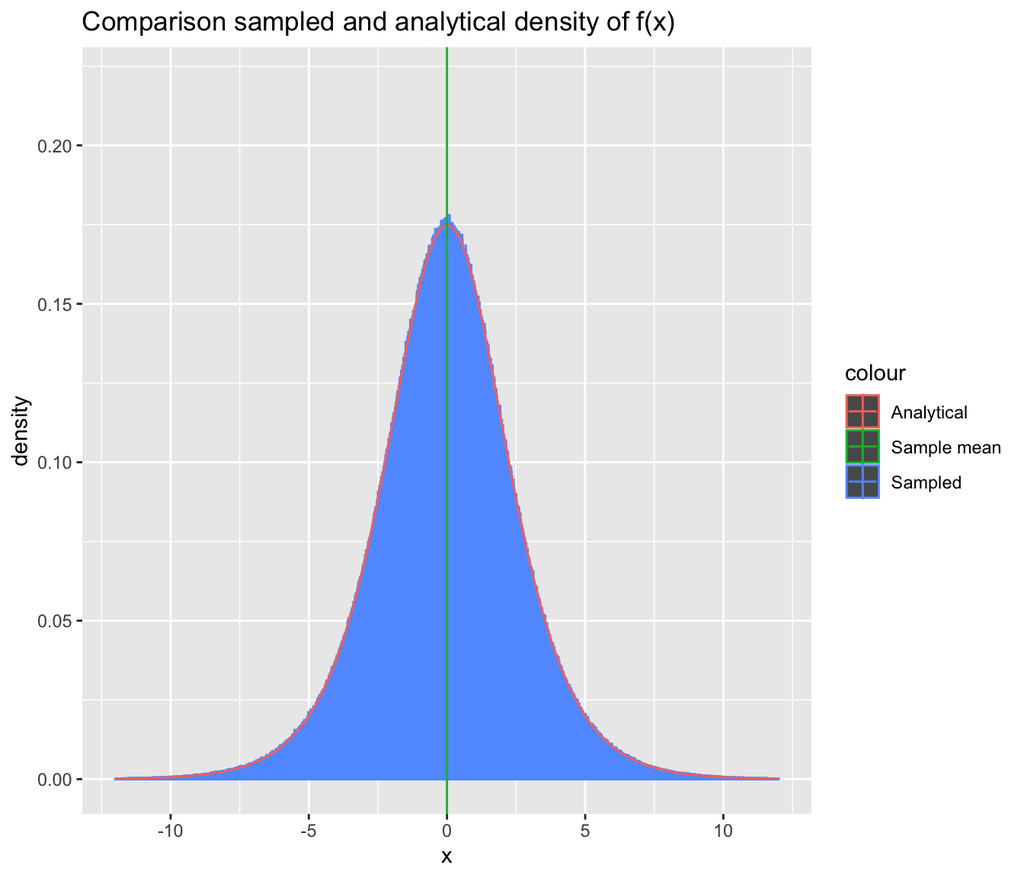

**Figure 3**: Comparing analytical and sampled density. Sampled density shown in blue bars and analytical of f(x) in red line. Sample mean is green vertical line.

```r
samples <- 1e+07
alpha <- 0.7
f_samples <- rf(n = samples, alpha = alpha)
ggplot() + geom_histogram(data = f_samples, mapping = aes(x = value,
    y = ..density.., color = "Sampled"), binwidth = 0.01, boundary = 0) +
    stat_function(fun = df, args = list(alpha = alpha), aes(col = "Analytical")) +
    geom_vline(aes(xintercept = mean(f_samples$value), col = "Sample mean")) +
    ylim(0, 0.22) + xlim(-12, 12) + ggtitle("Comparison sampled and analytical density of f(x)") +
    labs(x = "x", y = "density")
```

From **figure 3** we see that the analytical density overlaps with the sampled density and the algorithm works. We know compare sampled mean and variance with theoretical mean and variance.

```r
mean <- 0
second_moment <- c * (1/(alpha + 2) + 5/exp(1))
variance <- second_moment - mean^2
results <- list(mean = mean, sample_mean = mean(f_samples %>% use_series(value)),
    variance = variance, sample_variance = var(f_samples %>% use_series(value)))
print(results)
```

```
## $mean
## [1] 0
##
## $sample_mean
## [1] -0.0005264838
##
## $variance
## [1] 1.230074
##
## $sample_variance
## [1] 6.703762
```

## 4.

To sample from standard normal distribution we use the Box-Muller transformation. That is, given $x_1\sim U(0,1)$ and $x_2\sim \mathrm{Exp}(1/2)$ it follows that $y_1=\sqrt{x_2}\cos(2\pi x_1)$ and $y_2=\sqrt{x_2}\sin(2\pi x_1)$ are iid standard normal. Hence, $(y_1,y_2)\sim\mathcal{N}_2(\vec{0},\mathbf{I})$ is standard bivariate normal distributed and independent. When sampling $n$ numbers from the standard normal distrubution, the Box-Muller algorith is called $n/2$ times.

```r
box_muller = function(n) {
    x1 <- runif(n%/%2 + 1)
    x2 <- rexp(n%/%2 + 1, rate = 1/2) %>% use_series(value)
    y1 <- map2_dbl(x2, x1, ~sqrt(.x) * cos(.y * 2 * pi))
    y2 <- map2_dbl(x2, x1, ~sqrt(.x) * sin(.y * 2 * pi))
    return(c(y1, y2)[1:n])  # Return only n first random numbers.
}
```

Then we test for sample mean and variance against theoretical solution with $n=1000000$.

```r
dnorm_std = partial(dnorm, mean = 0, sd = 1)
n = 1e+06
x = box_muller(n)
sample <- tibble(value = x)
results <- list(mean = 0, sample_mean = mean(x), variance = 1, sample_variance = var(x))
results
```

```
## $mean
## [1] 0
##
## $sample_mean
## [1] -0.0008294016
##
## $variance
## [1] 1
##
## $sample_variance
## [1] 0.9978711
```

We observe that sampled mean and variance coincide well with theoretical values, and thus it is evident that the Box-Muller algorithm is correctly implemented. In addition we make a histogram of the samples and compare to analytical solution.

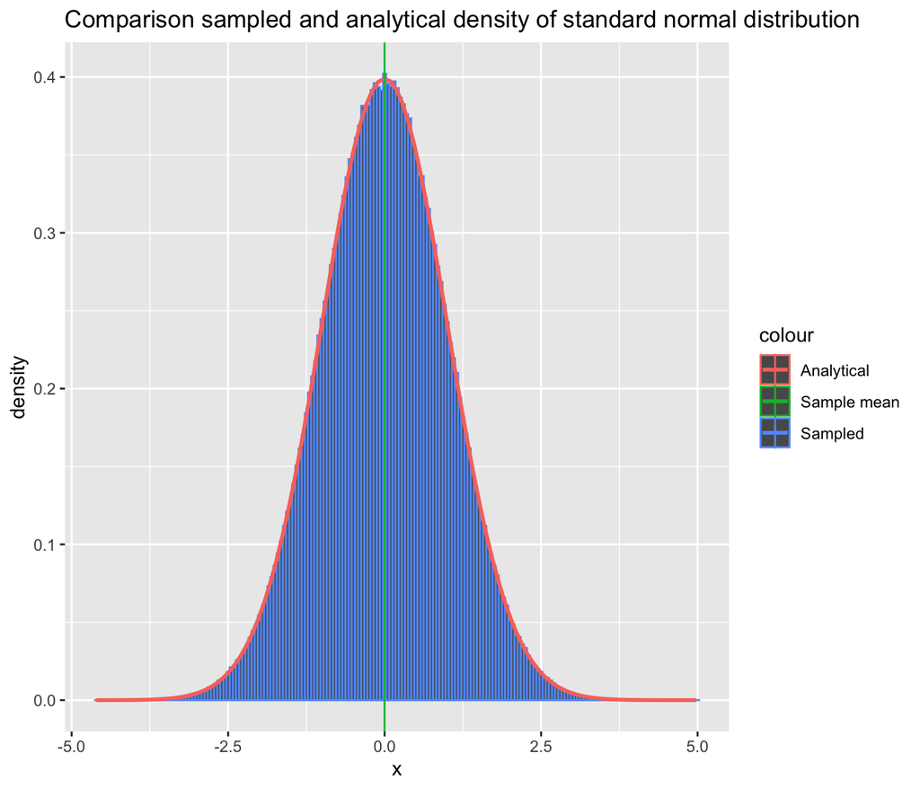

**Figure 4**: Comparing analytical and sampled density. Sampled density shown in blue bars and analytical of standard normal distribution in red line. Sample mean is green vertical line.

```r
ggplot() + geom_histogram(data = sample, aes(x = value, y = ..density..,
    color = "Sampled"), binwidth = 0.05) + stat_function(fun = dnorm_std,
    aes(color = "Analytical"), size = 1) + geom_vline(aes(xintercept = mean(x),
    col = "Sample mean")) + ggtitle("Comparison sampled and analytical density of standard normal distribution") +
    labs(x = "x", y = "density")
```

From **figure 4** we observe that sampled and theoretical density coincide. Now we make a QQ-plot of generated samples and test for normality with the Anderson-Darling normality test.

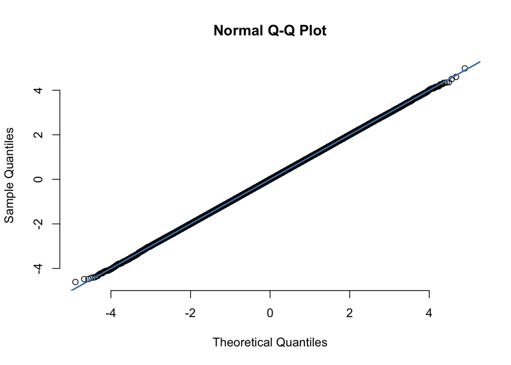

**Figure 5**: Normal QQ-plot to check for normality of data.

```r
qqnorm(x, pch = 1, frame = FALSE)
qqline(x, col = "steelblue", lwd = 2)
```

```r
library(nortest)
ad.test(x)
```

```
##
##  Anderson-Darling normality test
##
## data:  x
## A = 0.46069, p-value = 0.2601
```

The QQ-plot in **figure 5** and the Anderson-Darling test (p-value larger than 0.05 means that we do not reject null hypothesis of normality) indicate normality of data and thus our algorithm works.

## 5.

We now want to sample from a general $d$-variate normal distribution $\mathcal{N}_d(\mu,\Sigma)$. The simplest method is to generate $d$ iid standard normal samples and then apply the transformation

$$\begin{align}
y = \mu + A x \sim \mathcal{N}(\mu,AA^T)
\end{align}$$

where $\Sigma=AA^T$ and $x$ is the vector of iid standard normal samples generated by **box_muller** algorithm above. $A$ is found by Cholesky decomposition or SVD.

```r
# Function to draw one sample of a d-variate Normal(mu, sigma)
# variable
multivariate_normal <- function(mean, covariance) {
    d <- length(mean)
    A <- chol(covariance)
    x <- box_muller(d)
    y <- A %*% x + mean
    return(y)
}
```

Testing the implementation for $d=2$, $\mu=[1,4]^T$ and
$$\begin{align}
\Sigma=
\begin{pmatrix}
9.5 & 2.0\\
2.0 & 1.0
\end{pmatrix}
\end{align}$$
we get

```r
library(purrr)
mean = c(1, 4)
d = length(mean)
covariance = matrix(c(9.5, 2, 2, 1), ncol = d, nrow = d)
n = 10000
sample = matrix(NA, ncol = d, nrow = n)
for (i in 1:n) {
    sample[i, ] <- multivariate_normal(mean, covariance)  # Draw n samples
}
sample_mean = apply(sample, 2, mean)
sample_covariance = cov(sample)

results <- list(mean = mean, sample_mean = as.numeric(sample_mean), covariance = covariance,
    sample_covariance = as.matrix(sample_covariance))
colnames(results$sample_covariance) <- NULL
rownames(results$sample_covariance) <- NULL
print(results)
```

```
## $mean
## [1] 1 4
##
## $sample_mean
## [1] 0.9792531 3.9978433
##
## $covariance
##      [,1] [,2]
## [1,]  9.5    2
## [2,]  2.0    1
##
## $sample_covariance
##           [,1]      [,2]
## [1,] 9.7853271 0.4692987
## [2,] 0.4692987 0.5862611
```